# Episodic RL & Uncertainty: Experiment 5

Jonathan Nicholas and Daphna Shohamy

08/29/2018

*All analysis code is included at the end of the notebook*

This experiment is identical to experiment one, except object values are more continuous (varying in .1 increments from 0 - 1.2) rather than just discrete min (0) and max (1.2)

```python
sns.set_context("notebook")
```

```python
# Retrieve behavioral data for analysis
data = process_data()
train_data = data[(data.test_part == 'train') & (data.choice != 'no_response')]
test_data = data[(data.test_part == 'test') & (data.choice != 'no_response')]
```

# Training Phase Analysis

### Do participants learn to choose reliable > unreliable?

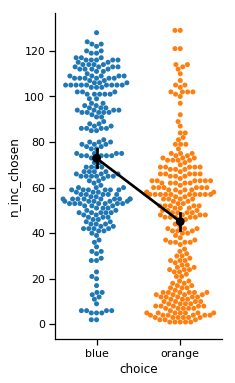

```python
plt.figure(figsize=(3,6))
train_deck_data = train_data[train_data.object_trial == False]
train_inc_data = train_deck_data.groupby(['subjectID','choice']).size().reset_index(name="n_inc_chosen")
sns.pointplot(x="choice",y="n_inc_chosen",color='k',data=train_inc_data)
a = sns.swarmplot(x="choice",y="n_inc_chosen",hue="choice",data=train_inc_data,zorder=0)
a.legend_.remove()
sns.despine(trim=False)
plt.show()
```

**Participants choose the reliable incremental option more frequently than the unreliable incremental option**

### Do participants learn to choose old > new?

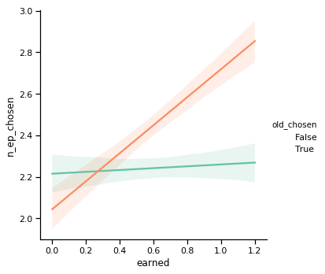

```python
train_object_data = train_data[train_data.object_trial == True]
train_old_data = train_object_data[train_object_data.old_trial == True]
train_ep_data = train_old_data.groupby(['subjectID','earned','old_chosen']).size().reset_index(name="n_ep_chosen")
train_ep_data.earned = train_ep_data.earned.astype(float)

sns.lmplot(x="earned",y="n_ep_chosen",hue="old_chosen",data=train_ep_data,palette="Set2",truncate=True,markers='');
```

**When an old object is shown, participants choose it more frequently than the new alternative. This difference increases with value.**

# Test Phase Analysis

```python
old_data = get_old_test(test_data=test_data )
print("N = %s"%(len(old_data.subjectID.unique())))
```

```
N = 250
```

### Do participants choose a greater number of high-value old objects when the incremental signal is reliable?

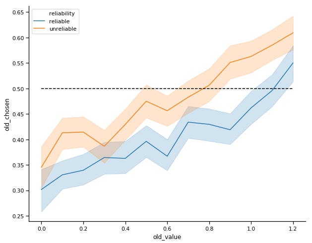

```python
sns.set_context("notebook")
plt.figure(figsize=(10,8))
f = sns.lineplot(x="old_value",y="old_chosen",hue="reliability",data=old_data,
             hue_order=['reliable','unreliable'])
sns.despine()
f.axes.plot((0,1.2),(0.5,0.5),'k--'); plt.show()
```

Visually, it appears that old objects are chosen more frequently with higher value and when the incremental signal is unreliable. The presence of an interaction is questionable, however.

```python
from bambi import Model
old_data['reliability_dummy'] = old_data['reliability'].apply(dummy_code_reliability)
model = Model(old_data)
results = model.fit("old_chosen ~ n_blurs + old_value*reliability", random='1|subjectID', family='bernoulli', samples=2000, chains=4)
```

```
Auto-assigning NUTS sampler...
Initializing NUTS using advi...
Convergence achieved at 32600
Interrupted at 32,599 [65%]: Average Loss = 22,438
Multiprocess sampling (4 chains in 4 jobs)
NUTS: [1|subjectID_offset, 1|subjectID_sd, old_value:reliability, old_value, n_blurs, reliability, Intercept]
The number of effective samples is smaller than 10% for some parameters.
```

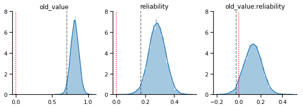

```python
plotLogisticModelOut(model)
# pm.traceplot(pm_trace); // plot traces for diagnostics
```

**Participants choose more old objects when the incremental signal is unreliable and as value increases. There is a very weak interaction between value and reliability, although the effect is quite small and 0 is within the 95% highest density interval.**

### Do participants also show higher false alarms (e.g. choosing new objects) when the incremental signal is unreliable?

```
                        Mixed Linear Model Regression Results
======================================================================================
Model:                     MixedLM          Dependent Variable:          object_chosen
No. Observations:          36752            Method:                      REML
No. Groups:                251              Scale:                       0.2035
Min. group size:           37               Likelihood:                  -23310.4786
Max. group size:           150              Converged:                   Yes
Mean group size:           146.4
--------------------------------------------------------------------------------------
                                            Coef.  Std.Err.   z    P>|z| [0.025 0.975]
--------------------------------------------------------------------------------------
Intercept                                    0.297    0.013 22.936 0.000  0.272  0.323
old_trial[T.True]                            0.112    0.007 16.160 0.000  0.098  0.126
reliability[T.unreliable]                    0.102    0.008 13.083 0.000  0.087  0.117
old_trial[T.True]:reliability[T.unreliable] -0.026    0.010 -2.616 0.009 -0.045 -0.006
Group Var                                    0.035    0.007
======================================================================================
```

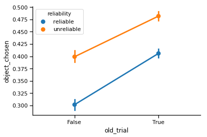

```python
test_data = addColumns4Plotting(test_data)
sns.pointplot(x="old_trial",y="object_chosen",hue="reliability",data=test_data)
sns.despine();

model = "object_chosen ~ old_trial*reliability"
md = smf.mixedlm(model, test_data, groups=test_data["subjectID"])
mdf = md.fit()
print(mdf.summary())
```

**Participants choose more objects in general when the incremental signal is unreliable (e.g. a greater number of both hits and false alarms)**

**Participants also choose more old objects than new objects**

This result indicates that we should look at a dprime measure rather than pure hit rate in order to account for this base rate of object choice during the unreliable condition

### Do participants show greater dprime for the unreliable condition and higher value old objects?

Here we define various signals as:

Hit = Proportion of old objects chosen on old trials **for each value**  
Miss = Proportion of old object not chosen on old trials **for each value**  
CR = Proportion of new objects not chosen on new trials  
FA = Proportion of new objects chosen on new trials

Hit Rate = Hit / (Hit + Miss) FA Rate = FA / (FA + CR)

dprime = z(Hit Rate) - z(FA Rate)

```python
signal_detection_df = getDPrimePerCondition(test_data)
```

```
                    Mixed Linear Model Regression Results
==============================================================================
Model:                    MixedLM        Dependent Variable:        dprime
No. Observations:         6261           Method:                    REML
No. Groups:               251            Scale:                     0.3360
Min. group size:          2              Likelihood:                -5833.7988
Max. group size:          26             Converged:                 Yes
Mean group size:          24.9
------------------------------------------------------------------------------
                                    Coef.  Std.Err.   z    P>|z| [0.025 0.975]
------------------------------------------------------------------------------
Intercept                            0.107    0.035  3.034 0.002  0.038  0.176
reliability[T.unreliable]           -0.202    0.028 -7.236 0.000 -0.257 -0.148
old_value                            0.336    0.028 12.072 0.000  0.281  0.390
old_value:reliability[T.unreliable]  0.041    0.039  1.048 0.295 -0.036  0.119
Group Var                            0.215    0.036
==============================================================================
```

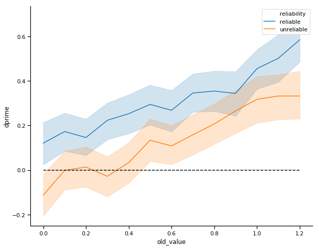

```python
sns.set_context("notebook")
plt.figure(figsize=(10,8))
f = sns.lineplot(x="old_value",y="dprime",hue="reliability",data=signal_detection_df)
sns.despine()
f.axes.plot((0,1.2),(0,0),'k--');

model = "dprime ~ old_value*reliability"
md = smf.mixedlm(model, signal_detection_df, groups=signal_detection_df["pid"])
mdf = md.fit()
print(mdf.summary())
```

**When accounting for false alarms, participants actually choose more old objects when the incremental signal is reliable. There is no interaction between value and reliability.**

### Do participants still show a preference for reliable > unreliable during test?

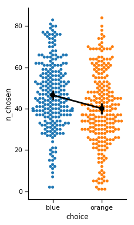

```python
test_choice_data = test_data.groupby(['subjectID','choice']).size().reset_index(name="n_chosen")
test_inc_choice_data = test_choice_data[(test_choice_data.choice == "blue") | (test_choice_data.choice == "orange")]

plt.figure(figsize=(3,6))
sns.pointplot(x="choice",y="n_chosen",color='k',data=test_inc_choice_data)
a = sns.swarmplot(x="choice",y="n_chosen",hue="choice",data=test_choice_data[(test_choice_data.choice == "blue") \
                                                                             | (test_choice_data.choice == "orange")],zorder=0)
a.legend_.remove()
sns.despine(trim=False)
plt.show()
```

**During test, participants still choose the reliable signal more frequently than the unreliable signal, although less strongly**

### Is reaction time related to old object choice and reliability?

```
                           Mixed Linear Model Regression Results
===========================================================================================
Model:                       MixedLM            Dependent Variable:            rt
No. Observations:            36752              Method:                        REML
No. Groups:                  251                Scale:                         63939.3229
Min. group size:             37                 Likelihood:                    -256083.1597
Max. group size:             150                Converged:                     Yes
Mean group size:             146.4
-------------------------------------------------------------------------------------------
                                              Coef.   Std.Err.   z    P>|z|  [0.025  0.975]
-------------------------------------------------------------------------------------------
Intercept                                     784.988   14.884 52.740 0.000 755.816 814.161
old_trial[T.True]                               7.760    3.886  1.997 0.046   0.144  15.375
reliability[T.unreliable]                       9.867    4.361  2.263 0.024   1.320  18.414
old_trial[T.True]:reliability[T.unreliable]     7.665    5.490  1.396 0.163  -3.095  18.424
Group Var                                   53228.499   19.057
===========================================================================================
```

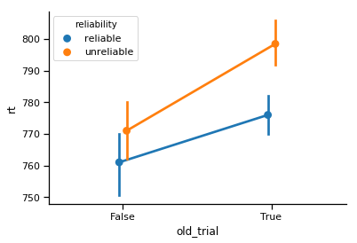

```python
sns.pointplot(x="old_trial",y="rt",hue="reliability",data=test_data,
              estimator=np.median,dodge=True)
sns.despine();

model = "rt ~ old_trial*reliability"
md = smf.mixedlm(model, test_data, groups=test_data["subjectID"])
mdf = md.fit()
print(mdf.summary())
```

**Participants take longer to respond on old trials than new trials**  
**Participants take longer to respond on unreliable trials than reliable trials**  
**There is an extremely small interaction between reliability and trial type (present with only 80% confidence)**

This indicates that internal processes for decisions relying on object recollection and reliability detection may be largely independent of one another, with slight overlap.

### On old trials, is reaction time greater when the old object was chosen? Is this related to reliability?

```
                       Mixed Linear Model Regression Results
====================================================================================
Model:                      MixedLM         Dependent Variable:         rt
No. Observations:           23207           Method:                     REML
No. Groups:                 250             Scale:                      63125.6672
Min. group size:            15              Likelihood:                 -161712.7657
Max. group size:            113             Converged:                  Yes
Mean group size:            92.8
------------------------------------------------------------------------------------
                                       Coef.   Std.Err.   z    P>|z|  [0.025  0.975]
------------------------------------------------------------------------------------
Intercept                              788.314   14.867 53.025 0.000 759.176 817.452
reliability[T.unreliable]               21.919    4.509  4.861 0.000  13.082  30.757
old_chosen                              17.335    4.984  3.478 0.001   7.566  27.103
reliability[T.unreliable]:old_chosen   -11.247    6.855 -1.641 0.101 -24.684   2.189
Group Var                            52843.332   19.204
====================================================================================
```

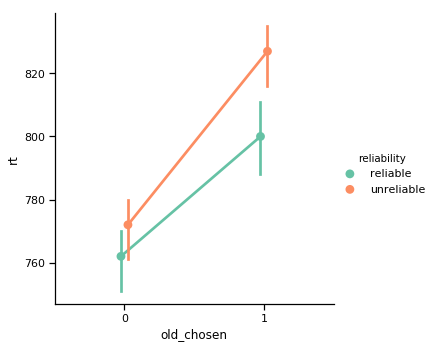

```python
sns.catplot(hue="reliability", y="rt",x='old_chosen',kind='point',dodge=True,
            data=old_data,truncate=True,palette="Set2",estimator=np.median)

model = "rt ~ reliability * old_chosen"
md = smf.mixedlm(model,old_data, groups=old_data["subjectID"])
mdf = md.fit()
print(mdf.summary())
```

```python
# Importing packages
# import rpy2
# %matplotlib inline
# %load_ext rpy2.ipython
from __future__ import division
import warnings, os
warnings.filterwarnings('ignore')
import numpy as np
import pandas as pd
import matplotlib.pyplot as plt
import seaborn as sns
import statsmodels.formula.api as smf

def process_data():

    global exclude_response
    global exclude_blur

    # these parameters exclude very few people
    exclude_response = .6
    exclude_blur = 100
    # Load the screentime data
    int_data, exclude_pids = loadData(dType="interaction")
    exclude_pids = map(int,exclude_pids)
    # Load the experiment data
    data = loadData(dType="experiment")[0]

    n_blurs = int_data[int_data.event == "blur"] \
                .groupby(['subjectID','event']) \
                .size() \
                .reset_index(name="n_blurs")

    def get_blurs(x):
        if str(x) in n_blurs.subjectID.unique():
            pid_blurs = n_blurs[n_blurs.subjectID == str(x)].n_blurs.iloc[0]
            return pid_blurs
        else:
            # if not there, then they don't have any blurs
            return 0

    data['n_blurs'] = data['subjectID'].apply(get_blurs)

    return data

def get_old_test(test_data=None,get_old=True):
    propResps = {'pid':[],'propResp':[]}
    for pid in data.subjectID.unique():
        pid_train_data = data[(data.test_part == 'train') & (data.subjectID == pid)]
        pid_test_data = data[(data.test_part == 'test') & (data.subjectID == pid)]

        bonus = pid_test_data.bonus.mean()

        nTrials = len(pid_train_data)+len(pid_test_data)

        cleaned_train = pid_train_data[pid_train_data.choice != 'no_response']
        cleaned_test = pid_test_data[pid_test_data.choice != 'no_response']

        nResponded = len(cleaned_train)+len(cleaned_test)
        proportionResponse = nResponded/nTrials
        propResps['pid'].append(pid)
        propResps['propResp'].append(proportionResponse)
    propResps = pd.DataFrame.from_dict(propResps)

    old_data = test_data[test_data.old_trial == get_old]

    def binarize_old_choice(row):
        if row.choice == "object":
            return 1#True
        else:
            return 0#False

    def get_reliability(row):
        if row.deck_type == "blue":
            return "reliable"
        elif row.deck_type == "orange":
            return "unreliable"

    def get_prop_response(row):
        prop_response = propResps[propResps.pid == row.subjectID].propResp.iloc[0]
        return prop_response

    old_data['old_chosen'] = old_data.apply(lambda row: binarize_old_choice(row),axis=1)
    old_data['reliability'] = old_data.apply(lambda row: get_reliability(row),axis=1)
    old_data['old_value'] = old_data['old_value'].astype('float')
    old_data['propResponse'] = old_data.apply(lambda row: get_prop_response(row),axis=1)

    old_data = old_data[old_data.propResponse >= 0.6]

    return old_data

def plot_generative(nTimepoints):
    reliableDist = np.round_(np.random.normal(0.6,0.05,nTimepoints),decimals=2)
    unreliableDist = np.round_(np.random.normal(0.6,0.2,nTimepoints),decimals=2)

    sns.distplot(reliableDist)
    sns.despine()
    plt.text(0.7,7,'Reliable',color='blue')
    sns.distplot(unreliableDist)
    plt.text(0.7,2.2,'Unreliable',color='orange')
    plt.plot([0,0],[0,10],'k--')
    plt.text(0.05,7,'Low value object',color='black')
    plt.plot([1.2,1.2],[0,10],'k--')
    plt.text(1.25,7,'High value object',color='black')
    plt.title('Outcome Generative Distributions')

def loadData(dType=None,dataDir="/Users/jonathan/shohamylab/jspych-exps/data/exp5",fileType="stateData"):
    data, exclude_pids = [], []
    dataFiles = [d for d in os.listdir(dataDir) if dType in d]
    for f in dataFiles:
        subData = pd.read_csv(os.path.join(dataDir,f))
        if dType == "interaction":
            if len(subData[subData.event == 'blur']) >= exclude_blur:
                exclude_pids.append(f.split('_')[0])
            subData['subjectID'] = [f.split('_')[0]] * len(subData)
        elif dType == "experiment":
            bonus = float(f.split('_')[2].replace('bonus',''))
            subData['bonus'] = [bonus] * len(subData)
        data.append(subData)
    data = pd.concat(data,ignore_index=True)
    return data, exclude_pids


def aggregateTestData(data=None, exclude_pids=None):

    pids = data.subjectID.unique()

    dOut = {'reliability':[],'value':[],'pOld':[],
            'pid':[],'bonus':[],'propResponse':[],
            'mean_rt':[],'n_rel':[],'n_unrel':[],'n_circle':[],'n_object':[],
            'n_old_high':[],'n_old_low':[],'n_new':[],'rt_old':[],'rt_new':[],
           'rt_rel':[],'rt_unrel':[],'rt_circle':[],'rt_object':[],'n_old_chosen':[]}
    for pid in pids:

        train_data = data[(data.test_part == 'train') & (data.subjectID == pid)]
        test_data = data[(data.test_part == 'test') & (data.subjectID == pid)]

        bonus = test_data.bonus.mean()

        nTrials = len(train_data)+len(test_data)

        cleaned_train = train_data[train_data.choice != 'no_response']
        cleaned_test = test_data[test_data.choice != 'no_response']

        nResponded = len(cleaned_train)+len(cleaned_test)
        proportionResponse = nResponded/nTrials

        old_test = cleaned_test[cleaned_test.old_trial == True]
        old_chosen = old_test[old_test.choice == 'object']

        if proportionResponse >= exclude_response and pid not in exclude_pids:

            colors = ['blue','orange']
            values = ['1.20','0.00']

            for c in colors:
                for v in values:
                    nTotal = len(old_test[(old_test.deck_type == c) & \
                                          (old_test.old_value == v)])
                    nChosen = len(old_chosen[(old_chosen.deck_type == c) & \
                                             (old_chosen.old_value == v)])

                    # number of object trials chosen
                    nOldHigh = len(cleaned_test[(cleaned_test.choice == "object") & \
                                                (cleaned_test.old_trial == True) & \
                                                (cleaned_test.old_value == '1.20')])
                    nOldLow = len(cleaned_test[(cleaned_test.choice == "object") & \
                                               (cleaned_test.old_trial == True) & \
                                               (cleaned_test.old_value == '0.00')])
```

```python
                    nNew = len(cleaned_test[(cleaned_test.choice == "object") & \
                                            (cleaned_test.old_trial == False)])
                    nObject = nOldHigh+nOldLow+nNew

                    rtOld = cleaned_test[(cleaned_test.choice == "object") & \
                                            (cleaned_test.old_trial == True)].rt.mean()
                    rtNew = cleaned_test[(cleaned_test.choice == "object") & \
                                            (cleaned_test.old_trial == False)].rt.mean()
                    rtObject = rtOld+rtNew

                    # number of circle trials chosen
                    nReliable = len(cleaned_test[(cleaned_test.choice == "blue")])
                    nUnreliable = len(cleaned_test[(cleaned_test.choice == "orange")])
                    nCircle = nReliable+nUnreliable

                    rtReliable = cleaned_test[cleaned_test.choice == "blue"].rt.mean()
                    rtUnreliable = cleaned_test[cleaned_test.choice == "orange"].rt.mean()
                    rtCircle = np.mean([rtReliable,rtUnreliable])

                    nTotalChoices = nObject+nCircle
                    # set in terms of proportions
                    nObject = nObject/nTotalChoices
                    nNew = nNew/nTotalChoices
                    nOldHigh = nOldHigh/nTotalChoices
                    nOldLow = nOldLow/nTotalChoices
                    nCircle = nCircle/nTotalChoices
                    nReliable = nReliable/nTotalChoices
                    nUnreliable = nUnreliable/nTotalChoices

                    # number of old chosen/number of total old trials
                    pOld = nChosen/nTotal
                    nOldChosen = nChosen

                    # mean RT for when the old items are chosen
                    meanRT = old_test[(old_test.deck_type == c) & \
                                    (old_test.old_value == v)].rt.mean()

                    if c == 'blue':
                        rel = 'reliable'
                    else:
                        rel = 'unreliable'

                    if v == '1.20':
                        val = 'high'
                    else:
                        val = 'low'

                    dOut['reliability'].append(rel)
                    dOut['value'].append(val)
                    dOut['pOld'].append(pOld)
                    dOut['pid'].append(pid)
                    dOut['bonus'].append(bonus)
                    dOut['propResponse'].append(proportionResponse)
                    dOut['mean_rt'].append(meanRT)
                    dOut['n_rel'].append(nReliable)
                    dOut['n_unrel'].append(nUnreliable)
                    dOut['n_circle'].append(nCircle)
                    dOut['n_old_high'].append(nOldHigh)
                    dOut['n_old_low'].append(nOldLow)
                    dOut['n_new'].append(nNew)
                    dOut['n_object'].append(nObject)
                    dOut['n_old_chosen'].append(nOldChosen)
                    dOut['rt_rel'].append(rtReliable)
                    dOut['rt_unrel'].append(rtUnreliable)
                    dOut['rt_circle'].append(rtCircle)
                    dOut['rt_old'].append(rtOld)
                    dOut['rt_new'].append(rtNew)
                    dOut['rt_object'].append(rtObject)


    dOut = pd.DataFrame.from_dict(dOut)
    return dOut

def binChoices(data=None, n_bins=None, trialType=None):

    pids = data.subjectID.unique()

    relOut = []
    for pid in pids:

        test_data = data[(data.test_part == 'train') & (data.subjectID == pid)]
        train_data = data[(data.test_part == 'train') & (data.subjectID == pid)]

        bonus = train_data.bonus.mean()

        nTrials = len(train_data)+len(test_data)

        cleaned_train = train_data[train_data.choice != 'no_response'].reset_index()
        cleaned_test = test_data[test_data.choice != 'no_response'].reset_index()

        cleaned_train.loc[cleaned_train['choice'].str.contains('object'), 'choice'] = 'object'

        currBin = 0
        binWidth = int(len(cleaned_train)/n_bins)
        bins = []
        for i_row, row in cleaned_train.iterrows():
            if i_row % binWidth == 0:
                if currBin != n_bins:
                    currBin+=1

            bins.append(currBin)
        cleaned_train['bin'] = bins

        nResponded = len(cleaned_train)+len(cleaned_test)
        proportionResponse = nResponded/nTrials

        if proportionResponse >= exclude_response and pid not in exclude_pids:
            if trialType == "reliability":
                rel_chosen = cleaned_train[cleaned_train.choice != "object"] \
                .groupby(['bin','choice']).size().reset_index(name="num_chosen")
            elif trialType == "object":
                rel_chosen = cleaned_train[(cleaned_train.choice == "object") &
                                           (cleaned_train.old_trial == True)] \
                .groupby(['bin','earned','old_chosen']).size().reset_index(name="num_chosen")
            rel_chosen['pid'] = [pid] * len(rel_chosen)
            relOut.append(rel_chosen)

    relOut = pd.concat(relOut)
    if trialType == "object": relOut['earned'] = relOut['earned'].convert_objects(convert_numeric=True)
    return relOut

def gen_random_performance(data=None,n_sims=None):

    # Let's try and model guessing behavior
    # e.g. how much would we expect them to earn if they were just guessing?
    import random

    test_data = data[(data.test_part == 'test')]

    random_perf = {'pid':[],'random_test':[],'actual_earnings':[]}
    for pid in test_data.subjectID.unique():

        pid_data = test_data[test_data.subjectID == pid]

        earnings = pid_data[pid_data.earned != 'none'].earned
        total_earnings = np.sum(pd.to_numeric(earnings))

        sim_earnings = []
        for sim in range(n_sims):

            test_earnings = 0

            for i_row, row in pid_data.iterrows():

                reliableSample = np.round_(np.random.normal(0.6,0.05,1),decimals=2)
                unreliableSample = np.round_(np.random.normal(0.6,0.2,1),decimals=2)
```

```python
                old_val = row.old_value
                deck_type = row.deck_type

                if old_val == 'none':
                    obj_val = random.choice([0,1.2])
                elif old_val == '0.00':
                    obj_val = 0
                elif old_val == '1.20':
                    obj_val = 1.2

                if deck_type == 'blue':
                    deck_val = reliableSample[0]
                else:
                    deck_val = unreliableSample[0]

                test_earnings+=random.choice([deck_val,obj_val])

            sim_earnings.append(test_earnings)

        random_perf['pid'].append(pid)
        random_perf['random_test'].append(np.mean(sim_earnings))
        random_perf['actual_earnings'].append(total_earnings)

    random_perf = pd.DataFrame.from_dict(random_perf)

    return random_perf

def get_blurs(x):
    if str(x) in n_blurs.subjectID.unique():
        pid_blurs = n_blurs[n_blurs.subjectID == str(x)].n_blurs.iloc[0]
        return pid_blurs
    else:
        # if not there, then they don't have any blurs
        return 0

def get_relative_perf(x):
    # calculate their performance relative to what is expected based on random guessing
    rand_perf = random_perf[random_perf.pid == x].random_test.iloc[0]
    actual_earnings = random_perf[random_perf.pid == x].actual_earnings.iloc[0]
    rel_perf = (actual_earnings*0.01) - (rand_perf*0.01)

    return rel_perf

def melt_choice_df(variables=[],col_name="None",data_subset=None):

    if data_subset == 'highvalobj':
        full_data = agg_data[agg_data.bestStrategy == "choosehighold"]
    else:
        full_data = agg_data

    plt_data = pd.melt(full_data, id_vars=['pid'], value_vars=variables)
    plt_data = plt_data.groupby(['pid','variable']).value.mean().reset_index(name=col_name)

    perf = []
    for pid in plt_data.pid.unique():
        d_length = len(plt_data[plt_data.pid == pid])
        perf.append([full_data[full_data.pid == pid].performance.iloc[0]] * d_length)
    perf = [i for j in perf for i in j]
    plt_data['performance'] = perf

    return plt_data

def plot_choices(data=None,yVal=None,colors=None,order=None):

#     sns.swarmplot(x='variable',y=yVal,data=plt_data,palette=colors,order=order)

    f, axes = plt.subplots(1,2,figsize=(12,6))
    sns.pointplot(x='variable',y=yVal,data=data,
                  hue='variable',order=order,hue_order=order,
                  join=False,ax=axes[0])

    sns.pointplot(x='variable',y=yVal,data=data,
                  color='black',order=order,join=False,ax=axes[1])
    sns.swarmplot(x='variable',y=yVal,data=plt_data,palette=colors,order=order,ax=axes[1])

    sns.lmplot(x='performance',y=yVal,hue='variable',data=data,
               palette=colors,hue_order=order)

def gen_strategy(data=None,strategy=None):

    # Model object-centric choice strategy
    # Choose an object only if it is high-value old
    import random

    test_data = data[(data.test_part == 'test')]

    perf = {'pid':[],strategy:[]}
    for pid in test_data.subjectID.unique():

        pid_data = test_data[test_data.subjectID == pid]

        earnings = pid_data[pid_data.earned != 'none'].earned
        total_earnings = np.sum(pd.to_numeric(earnings))

        agreement = 0
        for i_row, row in pid_data.iterrows():

            old_val = row.old_value
            deck_type = row.deck_type

            if strategy == 'choosehighold':

                if old_val == '1.20':
                    sim_choice = 'object'
                else:
                    sim_choice = 'deck'

            elif strategy == 'choosehighandnew':
                if old_val == '1.20' or old_val == 'none':
                    sim_choice = 'object'
                else:
                    sim_choice = 'deck'

            elif strategy == 'chooseold':

                if old_val == '1.20' or old_val == '0.00':
                    sim_choice = 'object'
                else:
                    sim_choice = 'deck'

            elif strategy == 'choosecircle':

                sim_choice = 'deck'

            elif strategy == 'chooseobject':

                sim_choice = 'object'

            elif strategy == 'chooserel':

                if deck_type == 'blue':
                    sim_choice = 'deck'
                else:
                    sim_choice = 'object'

            elif strategy == 'chooseunrel':

                if deck_type == 'orange':
                    sim_choice = 'deck'
                else:
                    sim_choice = 'object'

            elif strategy == 'random':

                sim_choice = random.choice(['object','deck'])

            if sim_choice == 'object':
                if row.choice =='object':
                    agree = 1
                else:
                    agree = 0
            elif sim_choice == 'deck':
                if row.choice == 'blue' or row.choice == 'orange':
                    agree = 1
                else:
                    agree = 0

            agreement+=agree

        agreement = agreement/len(pid_data)

        perf['pid'].append(pid)
        perf[strategy].append(agreement)

    perf = pd.DataFrame.from_dict(perf)

    return perf


def plt_indiv_strategies(x=None,y=None,corr=None):

    r, axes = plt.subplots(1,2,figsize=(10,4))

    r = sns.regplot(y=y,x=x,data=strategies,ax=axes[0])
    r.set_xlim(0,1)
    r.set_ylim(0,1)
    if corr == "negative":
        axes[0].plot((1,1),(1,1),'k--',)
    else:
        axes[0].plot((0,1),(0,1),'k--',)

    strategies['%s - %s'%(x,y)] = strategies[y] - strategies[x]
    sns.swarmplot(strategies['%s - %s'%(x,y)],zorder=1,ax=axes[1])
    f = sns.pointplot(strategies['%s - %s'%(x,y)],color='black',zorder=2,ax=axes[1])
    f.set_ylim(-0.25,0.25)
    axes[1].plot((0,0),(-1,1),'k--')
    plt.show()

def get_best_strategy(strategyDf):
    global s
    s = {'pid':[],'bestStrategy':[],'value':[]}
    for pid in strategyDf.pid.unique():
        pidData = strategyDf[strategyDf.pid == pid]
        maxRow = pidData.loc[pidData.value.argmax()]
        bestStrategy = maxRow.variable
        maxValue = maxRow.value
        s['pid'].append(pid)
        s['bestStrategy'].append(bestStrategy)
        s['value'].append(maxValue)
    s = pd.DataFrame.from_dict(s)
    s1 = s.groupby('bestStrategy').size().reset_index(name='tally')
    return s1
```

```python
def get_performance_by_strategy():
    s3 = []
    for pid in agg_data.pid.unique():
        pid_data = agg_data[agg_data.pid == pid]
        s3.append([strategies[strategies.pid == pid] \
                  ['choosecircle - choosehighold'].iloc[0]] * len(pid_data))
    s3 = [i for j in s3 for i in j]
    agg_data['highold - circle'] = s3


    s2 = []
    for pid in agg_data.pid.unique():
        pid_data = agg_data[agg_data.pid == pid]
        s2.append([s[s.pid == pid].bestStrategy.iloc[0]] * len(pid_data))
    s2 = [i for j in s2 for i in j]
    agg_data['bestStrategy'] = s2

    return agg_data

def getTestDataChoices():

    test_data = data[data.test_part == "test"]
    test_data = test_data[test_data.choice != 'no_response']

    dOut = {'pid':[],'choice_type':[],'n_chosen':[]}

    for pid in test_data.subjectID.unique():

        pid_data = test_data[test_data.subjectID == pid]
        trial_data = pid_data
        trial_data.loc[trial_data['choice'].str.contains('object'), 'choice'] = 'object'

        old_data = trial_data[trial_data.old_trial == True]

        old_chosen = old_data[old_data.choice == "object"]

        new_chosen = trial_data[(trial_data.choice == "object") & \
                                (trial_data.old_trial == False)]

        n_old_chosen = len(old_chosen)
        n_new_chosen = len(new_chosen)
        n_highold_chosen = len(old_chosen[old_chosen.earned == "1.20"])
        n_lowold_chosen = len(old_chosen[old_chosen.earned == "0.00"])
        n_unrel_chosen = len(trial_data[trial_data.choice == "blue"])
        n_rel_chosen = len(trial_data[trial_data.choice == "orange"])

        choice_values = [n_old_chosen,n_rel_chosen,n_unrel_chosen,
                         n_highold_chosen,n_lowold_chosen,n_new_chosen]
        for i, choiceType in enumerate(['n_old_chosen',
                                        'n_rel_chosen',
                                        'n_unrel_chosen',
                                        'n_highold_chosen',
                                        'n_lowold_chosen',
                                        'n_new_chosen']):


            dOut['choice_type'].append(choiceType)
            dOut['n_chosen'].append(choice_values[i])
            dOut['pid'].append(pid)

    dOut = pd.DataFrame.from_dict(dOut)
    return dOut

def plot_choice_differences(plt_type=None,task_part=None):
    if plt_type != "all":
        plt_data = train_choice_data[train_choice_data.trial_type == plt_type]
    else:
        if task_part == "test":
            plt_data = test_choice_data
        else:
            plt_data = train_choice_data

    rel_unrel_diff = np.array(plt_data[plt_data.choice_type == "n_rel_chosen"].n_chosen) - \
                     np.array(plt_data[plt_data.choice_type == "n_unrel_chosen"].n_chosen)

    high_low_diff = np.array(plt_data[plt_data.choice_type == "n_highold_chosen"].n_chosen) - \
                    np.array(plt_data[plt_data.choice_type == "n_lowold_chosen"].n_chosen)

    f, ax = plt.subplots(1,2,figsize=(14,1))
    plt.suptitle("%s trials"%(plt_type))
    # sns.swarmplot(rel_unrel_diff,["rel - unrel"] * len(rel_unrel_diff),ax=ax[0])
    sns.pointplot(rel_unrel_diff,["rel - unrel"] * len(rel_unrel_diff),ax=ax[0],color='k')
    ax[0].plot((0,0),(-1,2),'k--')

    # sns.swarmplot(high_low_diff,["high - low"] * len(rel_unrel_diff),ax=ax[1])
    sns.pointplot(high_low_diff,["high - low"] * len(rel_unrel_diff),ax=ax[1],color='k')
    ax[1].plot((0,0),(-1,2),'k--')

    for a in ax:
        a.set_xlim(-10,50)

    plt.show()

def addColumns4Plotting(test_data):
    def binarize_old_choice(row):
        if row.choice == "object":
            return 1 #True
        else:
            return 0 #False

    def get_reliability(row):
        if row.deck_type == "blue":
            return "reliable"
        elif row.deck_type == "orange":
            return "unreliable"

    def get_signal_outcomes(row):
        if row.old_trial == True:
            if row.choice == "object":
                return "hit"
            else:
                return "miss"
        elif row.old_trial == False:
            if row.choice == "object":
                return "fa"
            else:
                return "cr"

    test_data['signal_outcomes'] = test_data.apply(lambda row: get_signal_outcomes(row),axis=1)
    test_data['object_chosen'] = test_data.apply(lambda row: binarize_old_choice(row),axis=1)
    test_data['reliability'] = test_data.apply(lambda row: get_reliability(row),axis=1)

    return test_data

def getDPrimePerCondition(test_data):

    import scipy

    def compute_dprime(n_Hit=None, n_Miss=None, n_FA=None, n_CR=None):

        # Ratios
        hit_rate = n_Hit/(n_Hit + n_Miss)
        fa_rate = n_FA/(n_FA + n_CR)

        # Adjusted ratios
        hit_rate_adjusted = (n_Hit+ 0.5)/((n_Hit+ 0.5) + n_Miss + 1)
        fa_rate_adjusted = (n_FA+ 0.5)/((n_FA+ 0.5) + n_CR + 1)

        # dprime
        dprime = scipy.stats.norm.ppf(hit_rate_adjusted) - scipy.stats.norm.ppf(fa_rate_adjusted)

        return dprime


    signal_df = test_data.groupby(['subjectID','reliability','old_trial','old_value','signal_outcomes']) \
                           .size() \
                           .unstack(fill_value=0) \
                           .stack() \
                           .reset_index(name="signal_counts")

    old_only_df = signal_df[signal_df.old_trial == True]
    new_only_df = signal_df[signal_df.old_trial == False]
    signal_detection_df = {'pid':[],'old_value':[],'reliability':[],'dprime':[],'hits':[],'misses':[],'fas':[],'crs':[],'hit_rate':[],'fa_rate':[]}
    for pid in old_only_df.subjectID.unique():
        for rel in old_only_df.reliability.unique():
            for val in old_only_df.old_value.unique():
                curr_old = old_only_df[(old_only_df.subjectID == pid) & \
                                       (old_only_df.reliability == rel) & \
                                       (old_only_df.old_value == val)]
                curr_new = new_only_df[(new_only_df.subjectID == pid) & \
                                       (new_only_df.reliability == rel)]
                try:
```

```python
                    hits = curr_old[curr_old.signal_outcomes == "hit"].signal_counts.iloc[0]
                    misses = curr_old[curr_old.signal_outcomes == "miss"].signal_counts.iloc[0]
                    fas = curr_new[curr_new.signal_outcomes == "fa"].signal_counts.iloc[0]
                    crs = curr_new[curr_new.signal_outcomes == "cr"].signal_counts.iloc[0]

                    dprime = compute_dprime(n_Hit=hits,
                                            n_Miss=misses,
                                            n_FA=fas,
                                            n_CR=crs)

                    signal_detection_df['pid'].append(pid)
                    signal_detection_df['old_value'].append(val)
                    signal_detection_df['reliability'].append(rel)
                    signal_detection_df['dprime'].append(dprime)
                    signal_detection_df['hits'].append(hits)
                    signal_detection_df['misses'].append(misses)
                    signal_detection_df['fas'].append(fas)
                    signal_detection_df['crs'].append(crs)
                    signal_detection_df['hit_rate'].append(hits/(hits + misses))
                    signal_detection_df['fa_rate'].append(fas/(fas + crs))

                except:
                    pass

    signal_detection_df = pd.DataFrame.from_dict(signal_detection_df)
    signal_detection_df['old_value'] = signal_detection_df['old_value'].astype(float)

    return signal_detection_df

def dummy_code_reliability(x):
    if x == 'reliable':
        return 0
    elif x == 'unreliable':
        return 1

def plotLogisticModelOut(model):

    import pymc3 as pm
    pm_trace = model.backend.trace

    sns.set_context("notebook")

    f, axes = plt.subplots(1,3,figsize=(10,3))

    variables_to_plot = ['old_value','reliability','old_value:reliability']
    for i_var, var in enumerate(variables_to_plot):

        x_lower = pm.stats.hpd(pm_trace,alpha=0.05)[0][var][0]
        x_upper = pm.stats.hpd(pm_trace,alpha=0.05)[0][var][1]

        sns.distplot(np.reshape(pm_trace[var],8000),ax=axes[i_var])

        axes[i_var].plot((x_lower,x_lower),(0,8),'k--',alpha=0.5)
        #axes[i_var].plot((x_upper,x_upper),(0,35),'k--',alpha=0.5)
        axes[i_var].plot((0,0),(0,8),'r:');

        axes[i_var].set_title(var)
        axes[i_var].set_ylim(0,8)

        sns.despine(trim=False)
```